# Horseshoe model background

Arnie Seong

11 July 2025

# Background

The motivation for this model is to combine the variable selection properties of Bayesian spike-and-slab with the expressivity of a neural network. We do this by placing a spike-and-slab prior on the *rows* of a weight matrix $W$ representing one layer of a neural network.

## Notation:

- $X$: a $n \times I$ matrix, representing $n$ observations of $I$ covariates;
- $W$: an $I \times J$ weight matrix, representing $J$ neurons each receiving $I$ inputs;
- $b$: a length $J$ vector of biases (duplicated $n$ times and stacked into a $n \times J$ matrix)

We can then represent the computation performed by the first layer of a neural network as
$$XW + b = H,$$
where the output $H$ is the pre-activation. If $\sigma ()$ denotes the activation function (ReLU or otherwise), $\sigma(H) = \tilde{H}$ is the input for the next layer in the neural network).

Note that if all of the weights $w_{ij}$ in row $i$ of $W$ are 0, then the covariate in column $i$ of $X$ does not contribute to $H$ and therefore also has no effect on the final prediction. Thus by placing a spike-and-slab prior on the rows of $W$, we obtain variable selection.

We rely heavily here on the formulation and variational Bayes algorithm developed by *Louizos, Ullrich, Welling 2017*, who proposed using a group sparsity prior in order to reduce the size of the weight matrices in a neural network. Their primary focus is on decreasing the size of the neural network while preserving quality of prediction. Their method of placing a sparsity prior on the **rows** (indexed by $i \in \{1, 2, ..., I \}$) of $W$ leads to compression of the entire deep neural network, since if an entire row (or column) of weights is 0, then the dimension of the weight matrix can be reduced. Furthermore, if entire rows of a downstream layer are dropped, then the corresponding columns of *the preceding layer’s activations $H$* (and thus also the columns of the preceding layer’s $W$) can also be dropped. As their main concern is compression of the weight matrices, their discussion of what they term “the dropout parameter” ($\alpha_i$), is based around desired compression rates. Our work examines the potential of their formulation for principled variable selection.

## notes:

**How to differentiate ourselves from LUW 2017**:

- obvious, easy-to-accomplish contribution: provide empirical results on how good the method is at variable selection
  - different settings:
    - linear regression model
    - scalar-on-function regression
    - local null testing
    - under effect modification?
  - can we figure out a way to identify subgroups within population?
    - clues in first layer activations?
      - can we induce patterning in first layer activations? e.g. ReLU activations might give us a bunch of zeroes. Can we induce it to give one pattern of zeroes for one subgroup, another pattern for another subgroup? (This is more broadly applicable than just this method.)
- a more rigorous interpretation of the dropout parameter $\alpha_i$ as an analog to a Wald statistic
  - [Posterior-based Wald tests](https://www.sciencedirect.com/science/article/abs/pii/S0304407621002608)
  - [pdf without VPN](http://www.mysmu.edu/faculty/yujun/Research/ABT33.pdf)
- (Adam’s paper) using normalizing flow to model non-local prior
- (not a priority:) reconcile the mean-field assumption of Variational Bayes with group sparsity?
  - as *LUW 2017* note, **the priors do require independence between parameters** (but grouping by row creates dependence), so the joint Bayesian model developed in LUW 2017 is not strictly accurate and is more of an approximation (and then an approximation to an approximation b/c variational inference)
- brief note that we do not use the log-uniform / Normal-Jeffrey’s prior, as it will shrink all parameters to 0 given enough training time due to the asymptote in the prior $p(z_i) \propto 1 / |z_i|$ (pointed out by [Hron 2018](https://proceedings.mlr.press/v80/hron18a/hron18a.pdf)).

## single layer to multiple layers

- $i \in \{1, 2, ..., I\}$ indexes the rows of the weight matrix $W$, i.e. the inputs or covariates.
- $j \in \{1, 2, ...., J\}$ indexes the columns of $W$, i.e. the output’s dimensionality.

Thus, representing a fully connected layer of a neural network as $XW + b = H$, the components are:

- $X$: $n \times I$ matrix of covariates ($n$ observations of $I$ covariates)
- $W$: $I \times J$ weight matrix
- $b$: length $J$ intercept vector (gets “broadcast”, i.e. duplicated and stacked/rowbound to form a $n \times J$ matrix)
- $H$: $n \times J$ matrix representing the pre-activation

In a single-layer neural network, i.e. the familiar linear regression model, $H$ is our prediction $\hat{y}$.

In a multi-layer neural network, $H$ passes through some activation function $\sigma()$. This $\sigma(H) = \tilde H$ then becomes the input for the next layer.

Letting $\sigma()$ denote a chosen activation function, we might represent a deep neural network with $L$ layers as:

$$\begin{aligned}
X W_1 + b_1 = H_1
&& \text{first or input layer}
\\
\sigma(H_1)W_2 + b_2 = H_2
&& \text{first hidden layer}
\\
...
&& \text{more hidden layers}
\\
\sigma(H_{L-1})W_L + b_L = \hat{y}
&& \text{output layer}
\end{aligned}$$

Where the dimensions of the matrices (starting with $l = 2$) are:

- $W_l: J_{l-1} \times J_l$
- $b_l: n \times J_l$
- $H_l: n \times J_l$

# Horseshoe Model

Let

- $l \in \{1, 2, ..., L\}$ index the layers of the deep neural network,
- $i \in \{1, 2, ..., I_l\}$ index the rows of $W_l$ (weight matrix in layer $l$), and
- $j \in \{1, 2, ..., J_l\}$ index the columns.

Then the Bayesian model with a group-horseshoe prior on the rows of the weight matrices is:

$$\begin{aligned}
y
& \sim
N \left( f(W, X), \sigma^2 \right)
&& f(W, X) \text{ is the neural network }
\\
p(W|z)
& \sim
\prod_{l \in \{1, 2, ..., L\}, i \in \{1, 2, ..., I_l\}, j \in \{1,
2, ..., J_l\}} N(w_{l, i,j} | 0, z_{l, i}^2)
&& i, j \text{ index the columns and rows}
\\
z_{l,i}
& =
\underset{\text{local}}{\tilde{z}_{l,i}}
\times
\overset{\text{global}}{s_{l}}
\\
& \quad
\tilde{z}_{l, i}
\sim C^+(0,1)
&& \text{local scale parameter prior}
\\
& \quad
s
\sim C^+(0, \tau_0)
&& \text{global scale parameter prior; } \tau_0 \text{ a
tuning parameter}
\end{aligned}$$

- Note that if we let $w_{l,i,j} = \tilde{w}_{l,i,j} z_{l, i}$, then $\tilde{w}_{l,i,j} | z_{l,i} \sim N(0,1)$.

So that we will not need to formulate variational approximations to the half-Cauchy directly, we further decompose $\tilde{z}_{l,i} = \sqrt{\tilde{\alpha}_{l,i} \tilde{\beta}_{l,i}}$ and $s_l= \sqrt{s_{a_l} s_{b_l}}$ as follows:

- note: one $s$ per layer, i.e. $s_l$. In the decomposition $s_{a_l}$ and $s_{b_l}$, the *subscripts have subscripts*, i.e. $a_l$ and $b_l$. **Is this too confusing?**

$$\begin{aligned}
\tilde{z}_{l,i}
& =
\sqrt{
\tilde{\alpha}_{l,i}
\tilde{\beta}_{l,i}
}
\\
& \tilde{\alpha}_{l,i}
\sim \Gamma(1/2, 1)
\\
& \tilde{\beta}_{l,i}
\sim \text{Inv}\Gamma(1/2, 1)
\\
s_l &= \sqrt{s_{a_l} s_{b_l}}
&& \text{dropping layer subcript: } s = \sqrt{s_a s_b}
\\
& s_{a_l}
\sim \Gamma(1/2, \tau_0^2)
\\
& s_{b_l}
\sim \text{Inv}\Gamma(1/2, 1)
&&
\\
\end{aligned}$$

# Variational distributions

As we will have a large number of parameters, an MCMC approach is cost-prohibitive. Instead, we use variational Bayes with the following approximate posterior distributions $q_\phi(\cdot)$ (all are for an individual layer $l$)

$$\begin{aligned}
q_{\phi}(s_{a_l})
& =
logNormal(a_l | \mu_{s_{a_l}}, \sigma^2_{s_{a_l}})
\\
q_{\phi}(s_{b_l})
& =
logNormal(s_{b_l} | \mu_{s_{b_l}}, \sigma^2_{s_{b_l}})
\\
q_{\phi}(\tilde{\alpha}_l)
& =
\prod_{i \in \{1, 2, ..., I_l\}}
logNormal(\tilde{\alpha}_{l, i} | \mu_{\tilde{\alpha}_{l, i}},
\sigma^2_{\tilde{\alpha}_{l, i}})
\\
q_{\phi}(\tilde{\beta}_l)
& =
\prod_{i \in \{1, 2, ..., I_l\}} logNormal(\tilde{\beta}_{l, i} |
\mu_{\tilde{\beta}_{l, i}}, \sigma^2_{\tilde{\beta}_{l, i}})
\\
q_{\phi}(\tilde{W}_l)
& =
\prod_{i \in \{1, 2, ..., I_l\}, j \in \{1, 2, ..., J_l\}}
Normal(\tilde{w}_{l, i, j} | \mu_{\tilde{w}_{l, i, j}},
\sigma^2_{\tilde{w}_{l, i, j}})
\\
\end{aligned}$$

# ELBO and KL divergences

$$\begin{aligned}
-KL \left(
\underset{LogNorm}{q_\phi(s_a)} ||
\underset{Gamma}{p(s_a)}
\right)
& =
\log \tau_0
- \tau_0 \exp{\left( \mu_{s_a} +
\frac{1}{2}\sigma^2_{s_a} \right)}
+ \frac{1}{2} \left( \mu_{s_a} + \log \sigma^2_{s_a} + 1 + \log
2 \right)
\\
-KL \left(
\underset{LogNorm}{q_\phi(\tilde{\alpha})} ||
\underset{Gamma}{p(\tilde{\alpha})}
\right)
& =
\sum_i \left(
- \exp{\left( \mu_{\alpha_i} +
\frac{1}{2}\sigma^2_{\alpha_i} \right)}
+ \frac{1}{2}
\left( \mu_{\alpha_i} + \log \sigma^2_{\alpha_i} + 1 + \log 2
\right)
\right)
\\
-KL \left(
\underset{LogNorm}{q_\phi(s_b)} ||
\underset{InvGamma}{p(s_b)}
\right)
& =
- \exp{\left( - \mu_{s_b} + \frac{1}{2}\sigma^2_{s_b} \right)}
+ \frac{1}{2} \left( - \mu_{s_b} + \log \sigma^2_{s_b} + 1 + \log
2 \right)
\\
-KL \left(
\underset{LogNorm}{q_\phi(\tilde{\beta})} ||
\underset{InvGamma}{p(\tilde{\beta})}
\right)
& =
\sum_i
\left(
- \exp{
\left(
-\mu_{\tilde{\beta}_i}
+ \frac{1}{2} \sigma^2_{\tilde{\beta}_i}
\right)}
+ \frac{1}{2}
\left(
- \mu_{\tilde{\beta}_i} + \log \sigma^2_{\tilde{\beta}_i} + 1
+ \log 2
\right)
\right)
\\
-KL \left(
\underset{Norm}{q_\phi(W|z)} ||
\underset{Norm}{p(W|z)}
\right)
& =
- \frac{1}{2}
\sum_i \left(
\log{\frac{1}{\sigma^2_{\tilde{w}_{i,j}}}} +
\sigma^2_{\tilde{w}_i,j} + \mu^2_{\tilde{w}_{i,j}} - 1
\right)
\end{aligned}$$

- note: The expression for $-KL \left( q_\phi(W|z) || p(W|z) \right)$ is not dependent on $z$ because, under both the Bayesian model and the variational posterior formulation, $W = \tilde{W}z$:
  - under the model: $p(W|z) = \prod_{i,j} N(w_{i,j} | 0, z_i^2)$. Thus, if $W = \tilde{W}z$, then $\tilde{W}|z \sim \prod_{i,j} N(0,1)$, i.e. $\tilde{W}$ is independent of $z$
  - under the variational approximation, $\tilde{W} \sim \prod_{i,j} N(\mu_{\tilde{w}_{i,j}}, \sigma^2_{\tilde{w}_{i,j}})$ is independent of $z$ by construction (mean-field approximation)

# dropout parameter $\alpha_i$

For each row of the weight matrix $W_l$, we can obtain a dropout parameter $\alpha(\tilde{z}_i)$ based on the local shrinkage parameter $\tilde{z}_{i}$ i.e.

$$\alpha(\tilde{z}_i) = \frac{ Var \left(
\tilde{z}_{i} \right) }{ E^2 \left( \tilde{z}_{i}
\right) }$$

#### Note that this looks a whole lot like the inverse of a Wald statistic.

- https://www.sciencedirect.com/science/article/abs/pii/S0304407621002608
  - [link to pdf without VPN](http://www.mysmu.edu/faculty/yujun/Research/ABT33.pdf)

To derive this, we draw on properties of the LogNormal distribution (the variational distribution for the local shrinkage parameter $\tilde{z}_i$):

- If $Z \sim N(\mu, \sigma^2)$ and $X = e^Z \sim LogNormal(\mu, \sigma^2)$, then

$$\begin{aligned}
Var[X]
& =
\left( e^{\sigma^2} - 1 \right)
e^{\left( 2 \mu + \sigma^2 \right)}
\\
E[X]
& =
e^{ \left( \mu + \frac{\sigma^2}{2} \right) }
\\
\frac{Var{X}}{E^2[X]}
& =
e^{\sigma^2} - 1
\\
\end{aligned}$$

- if $X_1 \sim logNormal(\mu_1, \sigma^2_1)$ and $X_2 \sim LogNormal(\mu_2, \sigma^2_2)$ are independent, then

$$\sqrt{X_1 X_2} = \exp{
\left( \frac{1}{2}(Z_1 + Z_2) \right)} \sim LogNormal
\left( \frac{\mu_1 + \mu_2}{2}, \frac{\sigma^2_1 + \sigma^2_2}{4}
\right)$$

- Thus, since $\tilde{z}_i = \sqrt{\tilde{\alpha}_i \tilde{\beta}_i}$:

$$\begin{aligned}
\alpha(\tilde{z}_i)
& =
\frac{ Var \left( \tilde{z}_{i} \right) }
{ E^2 \left( \tilde{z}_{i} \right) }
=
\exp{\left(
\frac{ \sigma^2_{\tilde{\alpha}_i}
+ \sigma^2_{\tilde{\beta}_i } }
{4}
\right)}
- 1.
\end{aligned}$$

This dropout parameter $\alpha_{\tilde{z}_i}$ (referred to from now on just as $\alpha_i$) is our object of interest.

Also nice: the local shrinkage parameter controls the variational dropout rate only via its variance, which conforms nicely to the model since the *model* distribution $p(\tilde{z})$ is half-Cauchy (nonexistent expectation).

# Functional data test:

## Simulation setting:

- sparse truth (4 true covariates, 100 nuisance)
- number obs = 1000, 10000, 100000
- obs generated via additive model
  $$y =
  f_1(x_1) + f_2(x_2) + f_3(x_3) = f_4(x-4) + \epsilon, \quad \text{ with
  }\epsilon_i \sim N(0,1)$$

i.e. only the first 4 covariates in $X$ (out of 104) actually have an effect. Functions $f_1, f_2, f_3, f_4$ plotted below.

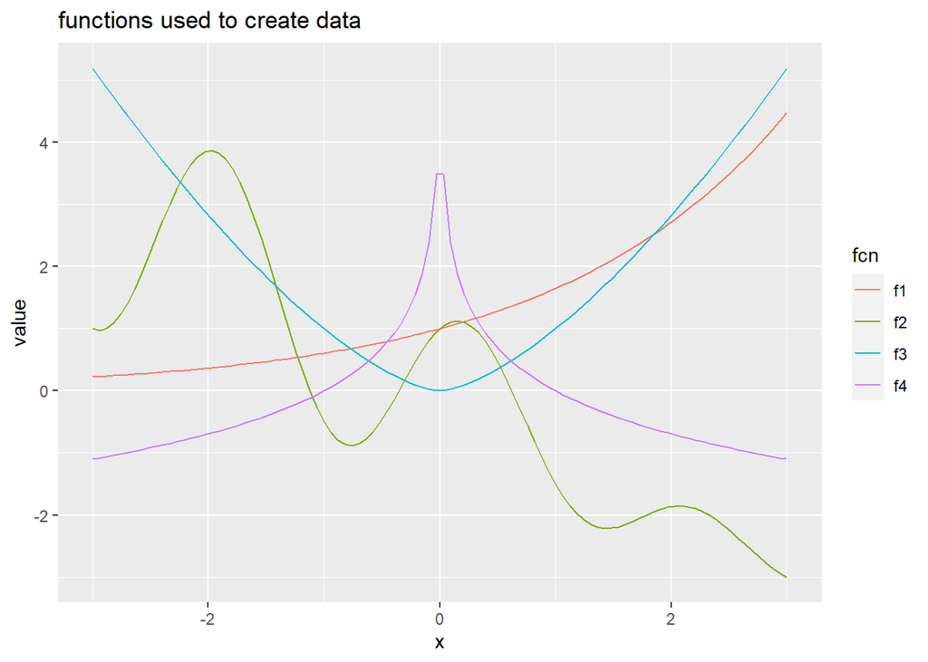

```r
fcn1 <- function(x) exp(x/2)
fcn2 <- function(x) cos(pi*x) + sin(pi/1.2*x) - x
fcn3 <- function(x) abs(x)^(1.5)
# fcn4 <- function(x) -x^2 / 2 -3
fcn4 <- function(x) - log(abs(x))
flist = list(fcn1, fcn2, fcn3, fcn4)

xshow <- seq(-3, 3, length.out = 100)
yshow <- sapply(flist, function(fcn) fcn(xshow))
df <- data.frame(
  "f1" = yshow[, 1],
  "f2" = yshow[, 2],
  "f3" = yshow[, 3],
  "f4" = yshow[, 4],
  "x"  = xshow
)
fcn_plt <- df %>%
  pivot_longer(cols = -x, names_to = "fcn") %>%
  ggplot(aes(y = value, x = x, color = fcn)) +
  geom_line() +
  labs(title = "functions used to create data")

fcn_plt
```

## single run performance

Need to run simulations on server, but results from 1 test are encouraging:

### n = 10k

```r
load(here::here("Rcode", "results", "hshoe_funcdata_n10k.Rdata"))
fcn_model <- torch_load(here::here("Rcode", "results", "hshoe_funcdata_n10k.pt"))

curvmat <- cbind(
  c(xshow, rep(0, 100*3)),
  c(rep(0, 100), xshow, rep(0, 100*2)),
  c(rep(0, 100*2), xshow, rep(0, 100)),
  c(rep(0, 100*3), xshow)
)
mat0 <- matrix(0, nrow = 400, ncol = 100)
x_plot <- torch_tensor(cbind(curvmat, mat0))

contents$plotdf$y <- as_array(fcn_model(x_plot))
```

#### dropout $\alpha_i$ (n = 10k)

For first layer only; $\alpha_i < 0.05$ in color.

```r
thresh <- 0.05
alph_tab <- round(as_array(fcn_model$fc1$get_dropout_rates()), 6)

alph_kable <- matrix(cell_spec(alph_tab, color = ifelse(alph_tab > thresh, "black", "blue")), ncol = 8)

mykable(alph_kable, cap = "dropout parameter $\\alpha_i$", escape = F)
```

dropout parameter $\alpha_i$

| 0.000149 | 0.253076 | 0.638827 | 0.751713 | 0.759395 | 0.263558 | 0.608075 | 0.252566 |
| --- | --- | --- | --- | --- | --- | --- | --- |
| 0.00001 | 0.419388 | 0.076635 | 0.647744 | 0.767995 | 0.496268 | 0.288583 | 0.507874 |
| 0.00004 | 0.05384 | 0.625454 | 0.425337 | 0.875977 | 0.154564 | 0.75923 | 0.22971 |
| 0.000085 | 0.224982 | 0.809539 | 0.269171 | 0.243799 | 0.840701 | 0.664855 | 0.059808 |
| 0.368959 | 0.924204 | 0.097026 | 0.047994 | 0.127251 | 0.89076 | 0.095093 | 0.321496 |
| 0.501382 | 0.1068 | 0.333435 | 0.03426 | 0.538519 | 0.428269 | 0.357621 | 0.299999 |
| 0.653517 | 0.21559 | 0.744866 | 0.186287 | 0.731063 | 0.064044 | 0.531249 | 0.798094 |
| 0.415738 | 0.087386 | 0.73823 | 0.748257 | 0.499845 | 0.167053 | 0.664497 | 0.205181 |
| 0.909159 | 0.225452 | 0.893296 | 0.641181 | 0.056408 | 0.459713 | 0.102519 | 0.217315 |
| 0.799501 | 0.815395 | 0.429873 | 0.755366 | 0.747017 | 0.465519 | 0.676489 | 0.311615 |
| 0.791355 | 0.107562 | 0.140571 | 0.117452 | 0.027939 | 0.604545 | 0.836304 | 0.913047 |
| 0.859238 | 0.59199 | 0.914079 | 0.046742 | 0.103396 | 0.771783 | 0.676208 | 0.502948 |
| 0.624415 | 0.743207 | 0.897815 | 0.846982 | 0.401066 | 0.596994 | 0.317891 | 0.843742 |

#### predicted/true functions (n=10k)

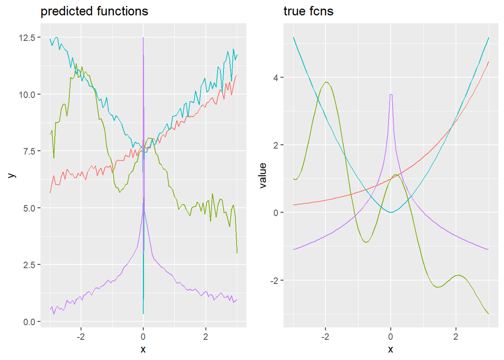

```r
pred_plt <- contents$plotdf %>%
  gather(key = "fcn", value = "x", -y) %>%
  ggplot(aes(y = y, x = x, color = fcn)) +
  geom_line() +
  labs(title = "predicted functions") +
  theme(legend.position="none")

fcn_plt <- fcn_plt +
  labs(title = "true fcns") +
  theme(legend.position="none")

grid.arrange(pred_plt, fcn_plt, nrow = 1)
```

### n = 100k

```r
load(here::here("Rcode", "results", "hshoe_funcdata_n100k.Rdata"))
fcn_model <- torch_load(here::here("Rcode", "results", "hshoe_funcdata_n100k.pt"))

curvmat <- cbind(
  c(xshow, rep(0, 100*3)),
  c(rep(0, 100), xshow, rep(0, 100*2)),
  c(rep(0, 100*2), xshow, rep(0, 100)),
  c(rep(0, 100*3), xshow)
)
mat0 <- matrix(0, nrow = 400, ncol = 100)
x_plot <- torch_tensor(cbind(curvmat, mat0))

contents$plotdf$y <- as_array(fcn_model(x_plot))
```

#### dropout $\alpha_i$ (n =100k)

For first layer only; $\alpha_i < 0.05$ in color.

```r
thresh <- 0.05
alph_tab <- round(as_array(fcn_model$fc1$get_dropout_rates()), 6)

alph_kable <- matrix(cell_spec(alph_tab, color = ifelse(alph_tab > thresh, "black", "blue")), ncol = 8)

mykable(alph_kable, cap = "dropout parameter $\\alpha_i$", escape = F)
```

dropout parameter $\alpha_i$

| 0.000016 | 0.604979 | 0.37535 | 0.057741 | 0.277066 | 0.764225 | 0.16741 | 0.929285 |
| --- | --- | --- | --- | --- | --- | --- | --- |
| 0.000001 | 0.202206 | 0.605311 | 0.360038 | 0.323118 | 0.286143 | 0.124122 | 0.429437 |
| 0.000003 | 0.738869 | 0.481367 | 0.417063 | 0.761356 | 0.914923 | 0.418458 | 0.445099 |
| 0.000009 | 0.509575 | 0.809985 | 0.618062 | 0.57866 | 0.493039 | 0.760611 | 0.531519 |
| 0.376588 | 0.501322 | 0.190381 | 1.012703 | 0.570719 | 0.548026 | 0.845776 | 0.919601 |
| 0.705082 | 0.784577 | 0.616623 | 0.674672 | 0.789829 | 0.288782 | 0.669384 | 0.531413 |
| 0.850769 | 0.405814 | 0.790277 | 0.109031 | 0.263218 | 0.887445 | 0.243586 | 0.777047 |
| 0.875954 | 0.779467 | 0.704279 | 0.404598 | 0.537105 | 0.810782 | 0.387957 | 0.419472 |
| 0.315197 | 0.397926 | 0.271848 | 0.60077 | 0.517787 | 0.9306 | 0.763316 | 0.223952 |
| 0.082196 | 0.519962 | 0.535632 | 0.774822 | 0.719829 | 0.832514 | 0.896441 | 0.270315 |
| 0.696237 | 0.187162 | 0.298994 | 0.654868 | 0.899172 | 0.23778 | 0.613312 | 0.481141 |
| 0.098694 | 0.249576 | 0.400642 | 0.686236 | 0.776848 | 0.757749 | 0.799141 | 0.446826 |
| 0.181344 | 0.60769 | 0.264868 | 0.104046 | 0.738156 | 0.393834 | 0.814795 | 0.291485 |

#### predicted/true functions (n=100k)

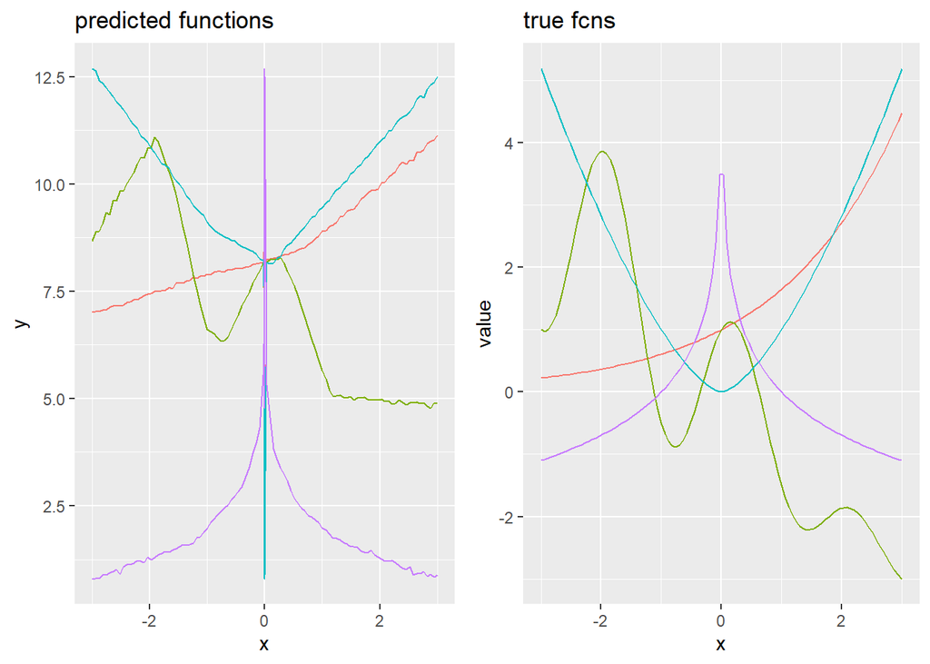

```r
pred_plt <- contents$plotdf %>%
  gather(key = "fcn", value = "x", -y) %>%
  ggplot(aes(y = y, x = x, color = fcn)) +
  geom_line() +
  labs(title = "predicted functions") +
  theme(legend.position="none")

fcn_plt <- fcn_plt +
  labs(title = "true fcns") +
  theme(legend.position="none")

grid.arrange(pred_plt, fcn_plt, nrow = 1)
```

# TO DO:

- get simulations running on servers
- read [Liu et al 2022, Posterior-based Wald-type statistics for hypothesis testing](https://www.sciencedirect.com/science/article/abs/pii/S0304407621002608); link to [pdf without VPN](http://www.mysmu.edu/faculty/yujun/Research/ABT33.pdf)
  - hope to clarify ideas on dropout parameter $\alpha_i$ as (the inverse of) a Wald-type statistic
- test to see how method performs under effect modification
- test to see how method performs using orthogonal cut basis
- use batch norming (pre-activation? or post-activation?) to speed up training?